# Hypothesis Testing

#### c) Does score accuracy on the triangular model task (testing phase) differ significantly between scaffold groups?

> Score improvement for the testing phase was significantly different between scaffold groups, F(1,163) = 20.47, p < 0.001 with a medium effect size, r = 0.33. Only the interactive depiction group saw increased performance from the TM model.

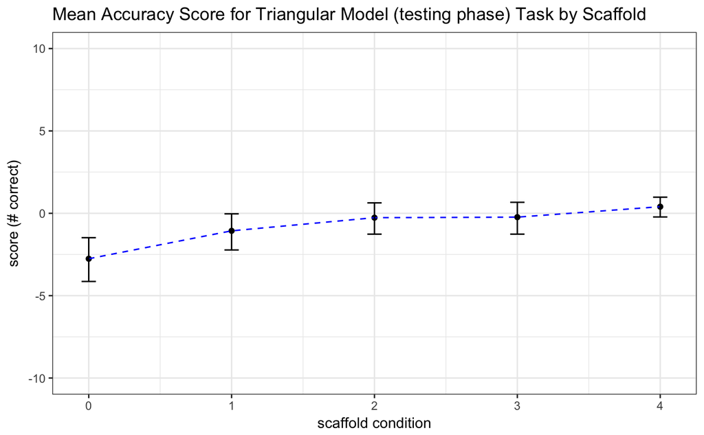

```
w.exp$condition: 0
     nbr.val     nbr.null       nbr.na          min          max        range          sum       median         mean      SE.mean
  29.0000000    1.0000000    0.0000000   -9.0000000    3.0000000   12.0000000  -80.0000000   -2.0000000   -2.7586207    0.6888542
CI.mean.0.95          var      std.dev     coef.var
   1.4110539   13.7610837    3.7095935   -1.3447276
--------------------------------------------------------------------------------------------------------
w.exp$condition: 1
     nbr.val     nbr.null       nbr.na          min          max        range          sum       median         mean      SE.mean
  31.0000000    4.0000000    0.0000000   -9.0000000    4.0000000   13.0000000  -33.0000000   -1.0000000   -1.0645161    0.5697301
CI.mean.0.95          var      std.dev     coef.var
   1.1635442   10.0623656    3.1721232   -2.9798733
--------------------------------------------------------------------------------------------------------
w.exp$condition: 2
     nbr.val     nbr.null       nbr.na          min          max        range          sum       median         mean      SE.mean
  30.0000000    5.0000000    0.0000000   -8.0000000    4.0000000   12.0000000   -8.0000000    0.0000000   -0.2666667    0.5095261
CI.mean.0.95          var      std.dev     coef.var
   1.0420979    7.7885057    2.7907894  -10.4654604
--------------------------------------------------------------------------------------------------------
w.exp$condition: 3
     nbr.val     nbr.null       nbr.na          min          max        range          sum       median         mean      SE.mean
  30.0000000    7.0000000    0.0000000   -6.0000000    3.0000000    9.0000000   -7.0000000    0.0000000   -0.2333333    0.5044249
CI.mean.0.95          var      std.dev     coef.var
   1.0316647    7.6333333    2.7628488  -11.8407804
--------------------------------------------------------------------------------------------------------
w.exp$condition: 4
     nbr.val     nbr.null       nbr.na          min          max        range          sum       median         mean      SE.mean
  45.0000000    7.0000000    0.0000000   -4.0000000    5.0000000    9.0000000   18.0000000    0.0000000    0.4000000    0.2971243
CI.mean.0.95          var      std.dev     coef.var
   0.5988146    3.9727273    1.9931702    4.9829254
```

```
w.exp$condition coerced to factor.
```

```
Levene's Test for Homogeneity of Variance (center = median)
       Df F value   Pr(>F)
group   4  3.8411 0.005223 **
      160
---
Signif. codes:  0 ‘***’ 0.001 ‘**’ 0.01 ‘*’ 0.05 ‘.’ 0.1 ‘ ’ 1
             Df Sum Sq Mean Sq F value   Pr(>F)
condition     1  167.7  167.69   20.47 1.16e-05 ***
Residuals   163 1335.0    8.19
---
Signif. codes:  0 ‘***’ 0.001 ‘**’ 0.01 ‘*’ 0.05 ‘.’ 0.1 ‘ ’ 1

Call:
aov(formula = test_diff ~ condition, data = w.exp)

Residuals:
    Min      1Q  Median      3Q     Max
-7.5125 -1.5855  0.4145  2.1055  5.4875

Coefficients:
            Estimate Std. Error t value Pr(>|t|)
(Intercept)  -2.1785     0.4016  -5.425 2.06e-07 ***
condition     0.6910     0.1527   4.525 1.16e-05 ***
---
Signif. codes:  0 ‘***’ 0.001 ‘**’ 0.01 ‘*’ 0.05 ‘.’ 0.1 ‘ ’ 1

Residual standard error: 2.862 on 163 degrees of freedom
Multiple R-squared:  0.1116,    Adjusted R-squared:  0.1061
F-statistic: 20.47 on 1 and 163 DF,  p-value: 1.16e-05
```

Levene’s is significant therefore should run Robust ANOVA… but anyway… 1 way independent means ANOVA is significant at p < 0.001. F(1,163) = 20.47, p < 0.001. Multiple R-squared = eta-squared = 0.1116, so r effect size = sqrt(0.1116) = 0.33.